# Eflows Species Clustering in CA Regions

## Overview and Basic Methods

In this version (June 2018) of the clustering, translocations were *not* included. Clusters must be contiguous in this version, as determined by a shared boundary or vertex, not by hydrologic connectivity. All HUCs were included except for those within the legal Delta, regardless of the minimum number of taxa (includes ones with one or none). Clustering was done with Flow Sensitive Taxa.

Clustering was done by a PISCES tool that subsets and formulates the data to be used by ArcGIS’ Grouping Analysis tool, where prior versions were clustered through manual steps and then fed into GeoDa’s K-Means tool.

## Map of Region Breakouts

The region was broken out primarily into * North Coast (North Coast->San Francisco) * South Coast (South of SF -> Southern California) * Central Valley (anything draining out through the Central Valley - excludes Honey/Eagle Lakes and SF Bay) * Great Basin (anything in hydrologic region 16 in the northern part of the state, contiguous) * Desert - not clustered or shown here as previous clustering indicated single-species driven areas (Includes eastern sierra that is part of region 18, souther reaches of region 15 in the state, portion of Colorado River, and a small piece of region 16)

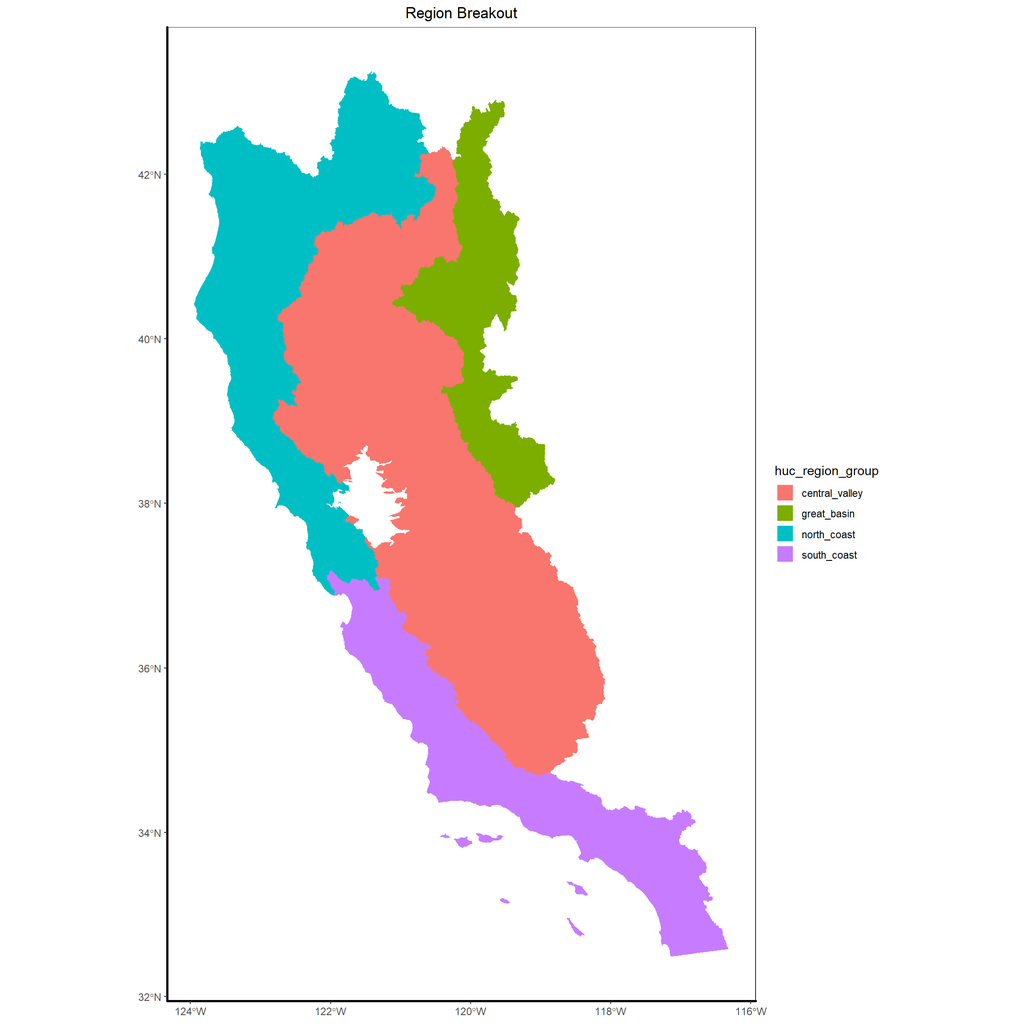

```r
writeLines("td, th { padding : 6px } th { background-color : #fff ; color : #000; border : 1px solid #333; } td { color : #000 ; border : 1px solid #333 }", con = "mystyle.css")  # add the CSS for the data tables

ggplot() +
  geom_sf(huc_data, lwd = 5, mapping=aes(fill=huc_region_group), color=NA)+
  ggtitle("Region Breakout") +
  theme_bw()+
  theme(panel.grid.major = element_line(colour = 'transparent'))+
  theme(strip.background = element_blank(), # facet theme control
        strip.placement = "outside",
        axis.line.x = element_line(color="black", size = 1),
        axis.line.y = element_line(color="black", size = 1),
        plot.title = element_text(hjust = 0.5))
```

## Central Valley

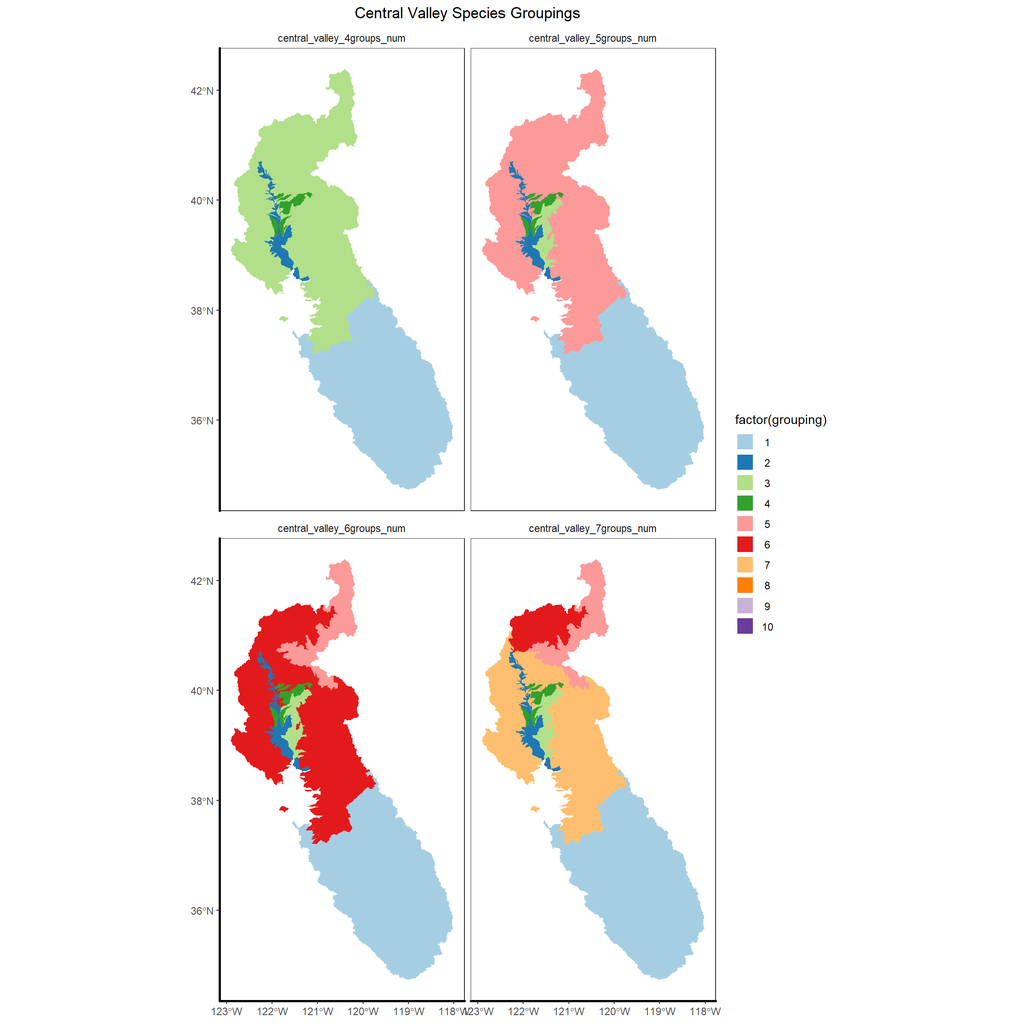

```r
cv_region_name = "central_valley"
cv_species_info <- species_maps(cv_region_name, "Central Valley", huc_data)
cv_species_info$region_map  # print the map
```

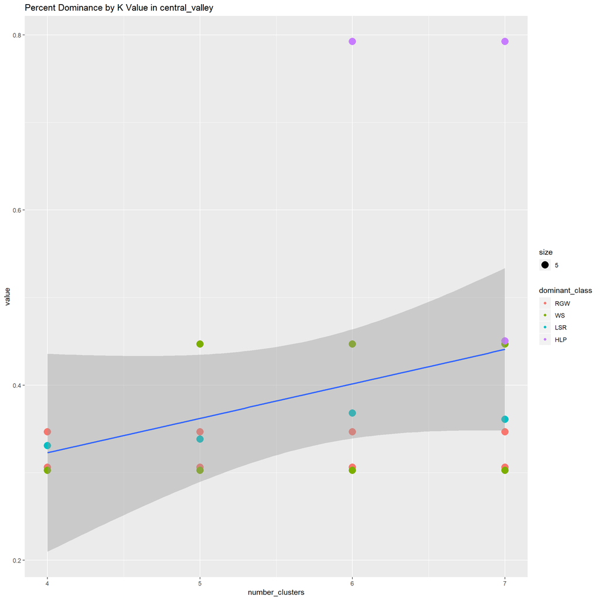

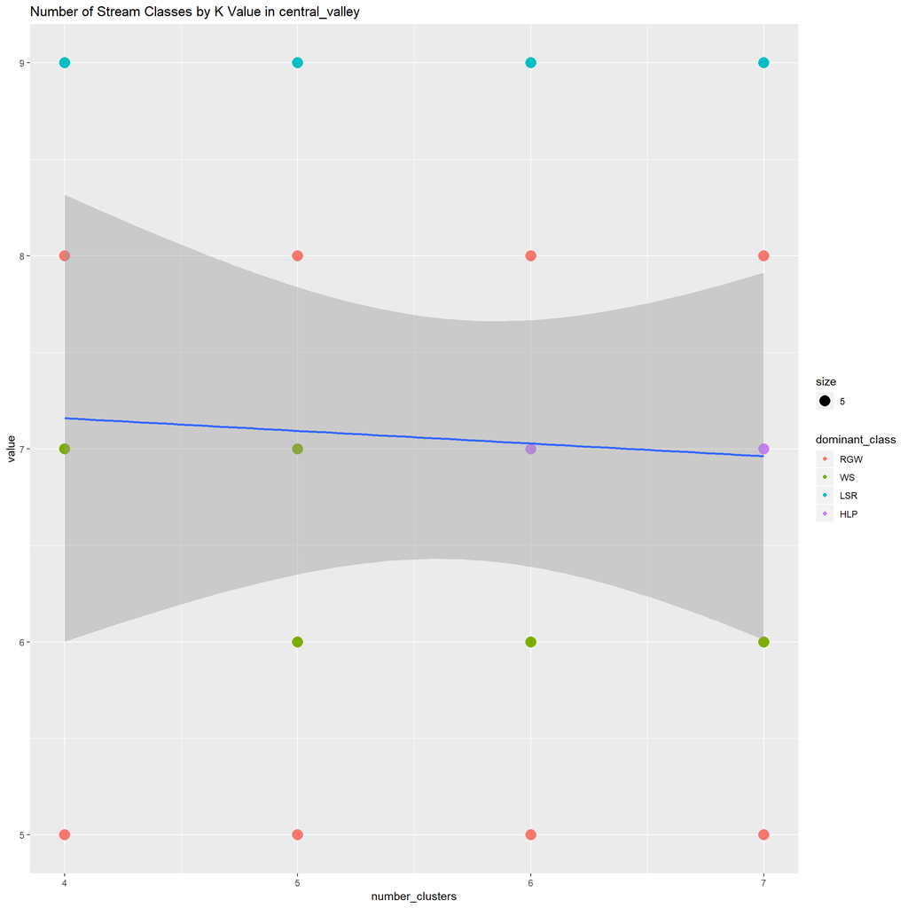

```r
print_dominance_plots(cv_species_info, cv_region_name)
```

```r
cv_species_lists <- species_lists_by_group_dfs(cv_species_info$species_data, cv_region_name)  # species_info$species_data is the data frame for the region
for(df in cv_species_lists){
  show(knitr::kable(df, format="html"))
}
```

| group_1 | group_2 | group_3 | group_4 |
| --- | --- | --- | --- |
| California_roach | California_roach | Bigeye_marbled_sculpin | California_roach |
| Central_Valley_fall_Chinook_salmon | Central_Valley_fall_Chinook_salmon | California_roach | Central_Valley_fall_Chinook_salmon |
| Central_Valley_late_fall_Chinook_salmon | Central_Valley_late_fall_Chinook_salmon | Central_Valley_fall_Chinook_salmon | Central_Valley_late_fall_Chinook_salmon |
| Hardhead | Central_Valley_spring_Chinook_salmon | Central_Valley_late_fall_Chinook_salmon | Central_Valley_spring_Chinook_salmon |
| Inland_threespine_stickleback | Central_Valley_winter_Chinook_salmon | Central_Valley_spring_Chinook_salmon | Hardhead |
| Kaweah_roach | Hardhead | Central_Valley_winter_Chinook_salmon | Inland_threespine_stickleback |
| Kern_brook_lamprey | Inland_threespine_stickleback | Hardhead | Pacific_lamprey |
| Kern_River_rainbow_trout | Pacific_lamprey | Inland_threespine_stickleback | Riffle_sculpin |
| Pacific_lamprey | Riffle_sculpin | Kern_brook_lamprey | River_lamprey |
| Riffle_sculpin | River_lamprey | Modoc_sucker | Sacramento_hitch |
| Sacramento_hitch | Sacramento_hitch | Northern_roach | Sacramento_pikeminnow |
| Sacramento_pikeminnow | Sacramento_pikeminnow | Pacific_lamprey | Sacramento_speckled_dace |
| Sacramento_splittail | Sacramento_speckled_dace | Pit_sculpin | Sacramento_splittail |
| Sacramento_sucker | Sacramento_splittail | Red_Hills_roach | Sacramento_sucker |
| NA | Sacramento_sucker | Riffle_sculpin | Sacramento_tule_perch |
| NA | Sacramento_tule_perch | River_lamprey | Western_brook_lamprey |
| NA | Southern_green_sturgeon | Sacramento_hitch | NA |
| NA | Western_brook_lamprey | Sacramento_pikeminnow | NA |
| NA | White_sturgeon | Sacramento_speckled_dace | NA |
| NA | NA | Sacramento_splittail | NA |
| NA | NA | Sacramento_sucker | NA |
| NA | NA | Sacramento_tule_perch | NA |
| NA | NA | Southern_green_sturgeon | NA |
| NA | NA | Western_brook_lamprey | NA |
| NA | NA | White_sturgeon | NA |

| group_1 | group_2 | group_3 | group_4 | group_5 |
| --- | --- | --- | --- | --- |
| California_roach | California_roach | California_roach | California_roach | Bigeye_marbled_sculpin |
| Central_Valley_fall_Chinook_salmon | Central_Valley_fall_Chinook_salmon | Central_Valley_fall_Chinook_salmon | Central_Valley_fall_Chinook_salmon | California_roach |
| Central_Valley_late_fall_Chinook_salmon | Central_Valley_late_fall_Chinook_salmon | Central_Valley_late_fall_Chinook_salmon | Central_Valley_late_fall_Chinook_salmon | Central_Valley_fall_Chinook_salmon |
| Hardhead | Central_Valley_spring_Chinook_salmon | Central_Valley_spring_Chinook_salmon | Central_Valley_spring_Chinook_salmon | Central_Valley_late_fall_Chinook_salmon |
| Inland_threespine_stickleback | Central_Valley_winter_Chinook_salmon | Hardhead | Hardhead | Central_Valley_spring_Chinook_salmon |
| Kaweah_roach | Hardhead | Inland_threespine_stickleback | Inland_threespine_stickleback | Central_Valley_winter_Chinook_salmon |
| Kern_brook_lamprey | Inland_threespine_stickleback | Pacific_lamprey | Pacific_lamprey | Hardhead |
| Kern_River_rainbow_trout | Pacific_lamprey | Riffle_sculpin | Riffle_sculpin | Inland_threespine_stickleback |
| Pacific_lamprey | Riffle_sculpin | Sacramento_hitch | River_lamprey | Kern_brook_lamprey |
| Riffle_sculpin | River_lamprey | Sacramento_pikeminnow | Sacramento_hitch | Modoc_sucker |
| Sacramento_hitch | Sacramento_hitch | Sacramento_splittail | Sacramento_pikeminnow | Northern_roach |
| Sacramento_pikeminnow | Sacramento_pikeminnow | Sacramento_sucker | Sacramento_speckled_dace | Pacific_lamprey |
| Sacramento_splittail | Sacramento_speckled_dace | Sacramento_tule_perch | Sacramento_splittail | Pit_sculpin |
| Sacramento_sucker | Sacramento_splittail | Southern_green_sturgeon | Sacramento_sucker | Red_Hills_roach |
| NA | Sacramento_sucker | Western_brook_lamprey | Sacramento_tule_perch | Riffle_sculpin |
| NA | Sacramento_tule_perch | White_sturgeon | Western_brook_lamprey | River_lamprey |
| NA | Southern_green_sturgeon | NA | NA | Sacramento_hitch |
| NA | Western_brook_lamprey | NA | NA | Sacramento_pikeminnow |
| NA | White_sturgeon | NA | NA | Sacramento_speckled_dace |
| NA | NA | NA | NA | Sacramento_splittail |
| NA | NA | NA | NA | Sacramento_sucker |
| NA | NA | NA | NA | Sacramento_tule_perch |
| NA | NA | NA | NA | Southern_green_sturgeon |
| NA | NA | NA | NA | Western_brook_lamprey |
| NA | NA | NA | NA | White_sturgeon |

| group_1 | group_2 | group_3 | group_4 | group_5 | group_6 |
| --- | --- | --- | --- | --- | --- |
| California_roach | California_roach | California_roach | California_roach | Hardhead | Bigeye_marbled_sculpin |
| Central_Valley_fall_Chinook_salmon | Central_Valley_fall_Chinook_salmon | Central_Valley_fall_Chinook_salmon | Central_Valley_fall_Chinook_salmon | Northern_roach | California_roach |
| Central_Valley_late_fall_Chinook_salmon | Central_Valley_late_fall_Chinook_salmon | Central_Valley_late_fall_Chinook_salmon | Central_Valley_late_fall_Chinook_salmon | Pit_sculpin | Central_Valley_fall_Chinook_salmon |
| Hardhead | Central_Valley_spring_Chinook_salmon | Central_Valley_spring_Chinook_salmon | Central_Valley_spring_Chinook_salmon | Sacramento_pikeminnow | Central_Valley_late_fall_Chinook_salmon |
| Inland_threespine_stickleback | Central_Valley_winter_Chinook_salmon | Hardhead | Hardhead | Sacramento_speckled_dace | Central_Valley_spring_Chinook_salmon |
| Kaweah_roach | Hardhead | Inland_threespine_stickleback | Inland_threespine_stickleback | Sacramento_sucker | Central_Valley_winter_Chinook_salmon |
| Kern_brook_lamprey | Inland_threespine_stickleback | Pacific_lamprey | Pacific_lamprey | NA | Hardhead |
| Kern_River_rainbow_trout | Pacific_lamprey | Riffle_sculpin | Riffle_sculpin | NA | Inland_threespine_stickleback |
| Pacific_lamprey | Riffle_sculpin | Sacramento_hitch | River_lamprey | NA | Kern_brook_lamprey |
| Riffle_sculpin | River_lamprey | Sacramento_pikeminnow | Sacramento_hitch | NA | Modoc_sucker |
| Sacramento_hitch | Sacramento_hitch | Sacramento_splittail | Sacramento_pikeminnow | NA | Northern_roach |
| Sacramento_pikeminnow | Sacramento_pikeminnow | Sacramento_sucker | Sacramento_speckled_dace | NA | Pacific_lamprey |
| Sacramento_splittail | Sacramento_speckled_dace | Sacramento_tule_perch | Sacramento_splittail | NA | Pit_sculpin |
| Sacramento_sucker | Sacramento_splittail | Southern_green_sturgeon | Sacramento_sucker | NA | Red_Hills_roach |
| NA | Sacramento_sucker | Western_brook_lamprey | Sacramento_tule_perch | NA | Riffle_sculpin |
| NA | Sacramento_tule_perch | White_sturgeon | Western_brook_lamprey | NA | River_lamprey |
| NA | Southern_green_sturgeon | NA | NA | NA | Sacramento_hitch |
| NA | Western_brook_lamprey | NA | NA | NA | Sacramento_pikeminnow |
| NA | White_sturgeon | NA | NA | NA | Sacramento_speckled_dace |
| NA | NA | NA | NA | NA | Sacramento_splittail |
| NA | NA | NA | NA | NA | Sacramento_sucker |
| NA | NA | NA | NA | NA | Sacramento_tule_perch |
| NA | NA | NA | NA | NA | Southern_green_sturgeon |
| NA | NA | NA | NA | NA | Western_brook_lamprey |
| NA | NA | NA | NA | NA | White_sturgeon |

| group_1 | group_2 | group_3 | group_4 | group_5 | group_6 | group_7 |
| --- | --- | --- | --- | --- | --- | --- |
| California_roach | California_roach | California_roach | California_roach | Hardhead | Bigeye_marbled_sculpin | California_roach |
| Central_Valley_fall_Chinook_salmon | Central_Valley_fall_Chinook_salmon | Central_Valley_fall_Chinook_salmon | Central_Valley_fall_Chinook_salmon | Northern_roach | California_roach | Central_Valley_fall_Chinook_salmon |
| Central_Valley_late_fall_Chinook_salmon | Central_Valley_late_fall_Chinook_salmon | Central_Valley_late_fall_Chinook_salmon | Central_Valley_late_fall_Chinook_salmon | Pit_sculpin | Hardhead | Central_Valley_late_fall_Chinook_salmon |
| Hardhead | Central_Valley_spring_Chinook_salmon | Central_Valley_spring_Chinook_salmon | Central_Valley_spring_Chinook_salmon | Sacramento_pikeminnow | Modoc_sucker | Central_Valley_spring_Chinook_salmon |
| Inland_threespine_stickleback | Central_Valley_winter_Chinook_salmon | Hardhead | Hardhead | Sacramento_speckled_dace | Northern_roach | Central_Valley_winter_Chinook_salmon |
| Kaweah_roach | Hardhead | Inland_threespine_stickleback | Inland_threespine_stickleback | Sacramento_sucker | Pit_sculpin | Hardhead |
| Kern_brook_lamprey | Inland_threespine_stickleback | Pacific_lamprey | Pacific_lamprey | NA | Riffle_sculpin | Inland_threespine_stickleback |
| Kern_River_rainbow_trout | Pacific_lamprey | Riffle_sculpin | Riffle_sculpin | NA | Sacramento_pikeminnow | Kern_brook_lamprey |
| Pacific_lamprey | Riffle_sculpin | Sacramento_hitch | River_lamprey | NA | Sacramento_speckled_dace | Pacific_lamprey |
| Riffle_sculpin | River_lamprey | Sacramento_pikeminnow | Sacramento_hitch | NA | Sacramento_sucker | Red_Hills_roach |
| Sacramento_hitch | Sacramento_hitch | Sacramento_splittail | Sacramento_pikeminnow | NA | Sacramento_tule_perch | Riffle_sculpin |
| Sacramento_pikeminnow | Sacramento_pikeminnow | Sacramento_sucker | Sacramento_speckled_dace | NA | NA | River_lamprey |
| Sacramento_splittail | Sacramento_speckled_dace | Sacramento_tule_perch | Sacramento_splittail | NA | NA | Sacramento_hitch |
| Sacramento_sucker | Sacramento_splittail | Southern_green_sturgeon | Sacramento_sucker | NA | NA | Sacramento_pikeminnow |
| NA | Sacramento_sucker | Western_brook_lamprey | Sacramento_tule_perch | NA | NA | Sacramento_speckled_dace |
| NA | Sacramento_tule_perch | White_sturgeon | Western_brook_lamprey | NA | NA | Sacramento_splittail |
| NA | Southern_green_sturgeon | NA | NA | NA | NA | Sacramento_sucker |
| NA | Western_brook_lamprey | NA | NA | NA | NA | Sacramento_tule_perch |
| NA | White_sturgeon | NA | NA | NA | NA | Southern_green_sturgeon |
| NA | NA | NA | NA | NA | NA | Western_brook_lamprey |
| NA | NA | NA | NA | NA | NA | White_sturgeon |

## Great Basin

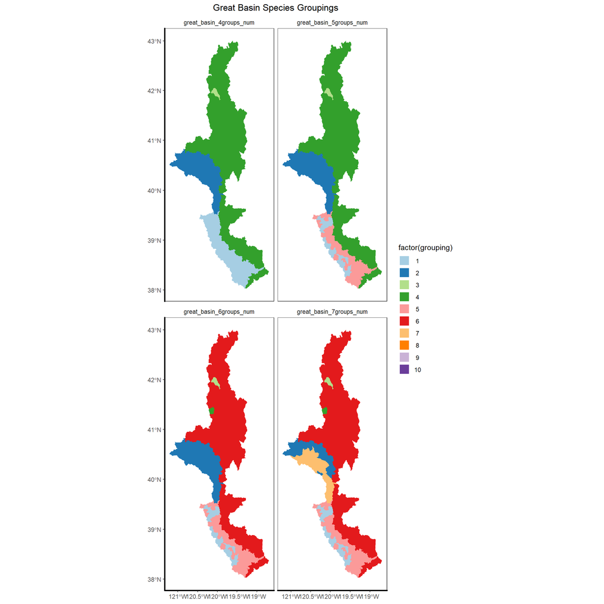

```r
gb_region_name <- "great_basin"
gb_species_info <- species_maps(gb_region_name, "Great Basin", huc_data)
gb_species_info$region_map  # print the map
```

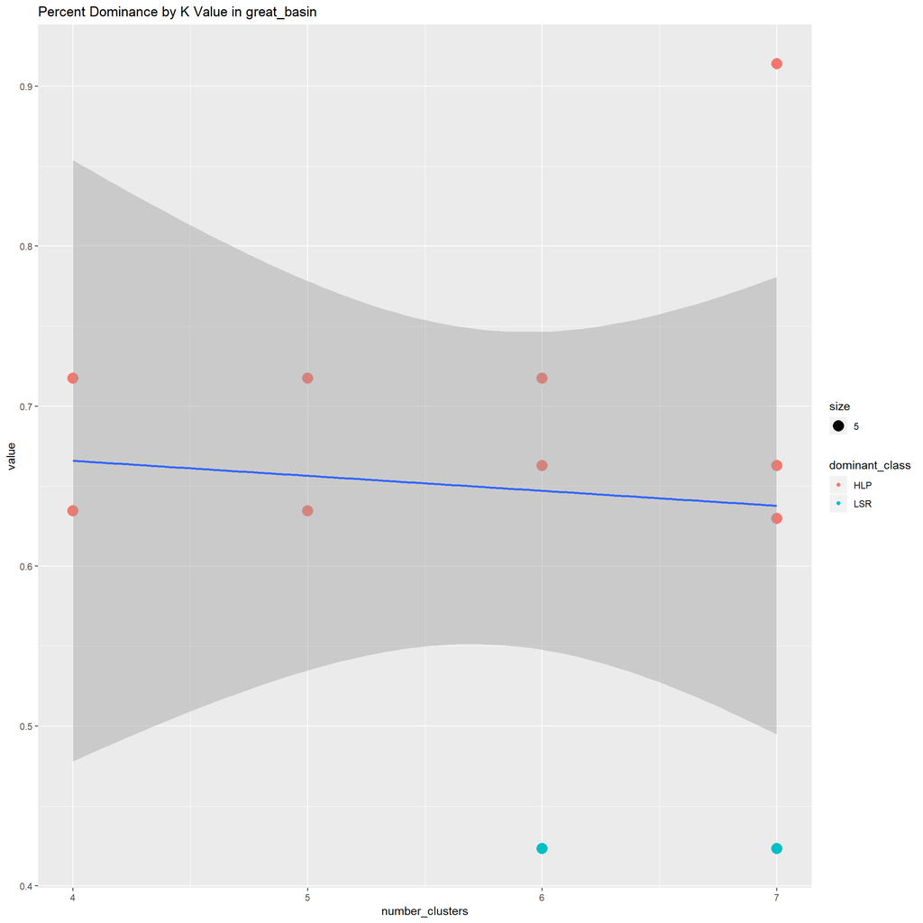

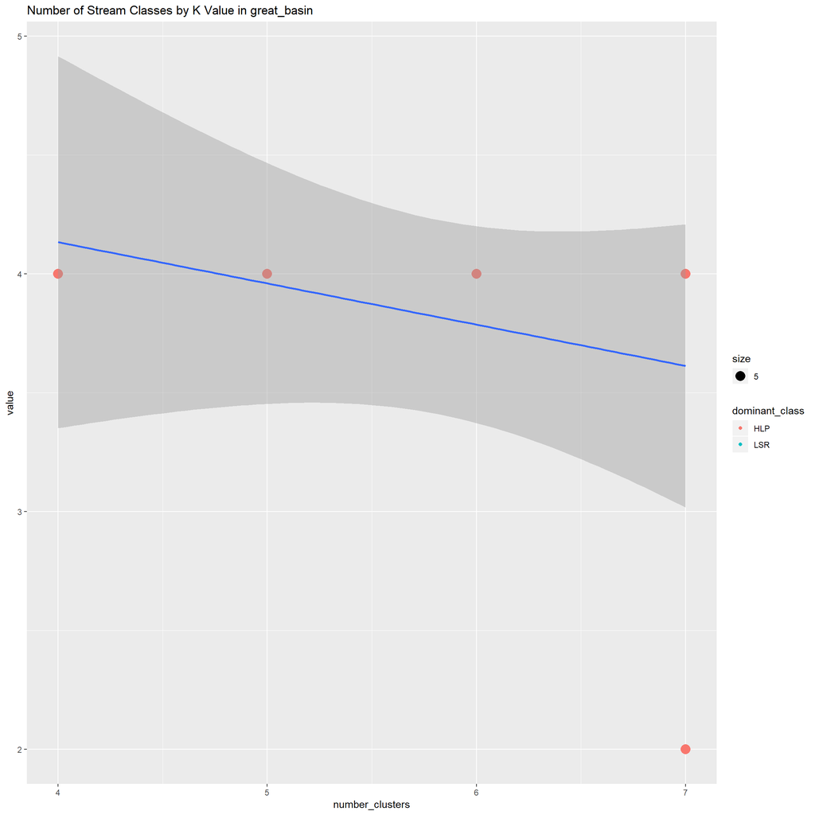

```r
print_dominance_plots(gb_species_info, gb_region_name)
```

```r
gb_species_lists <- species_lists_by_group_dfs(gb_species_info$species_data, gb_region_name)  # species_info$species_data is the data frame for the region
for(df in gb_species_lists){
  show(knitr::kable(df, format="html"))
}
```

| group_1 | group_2 | group_3 | group_4 |
| --- | --- | --- | --- |
| Lahontan_cutthroat_trout | Lahontan_mountain_sucker | Sacramento_speckled_dace | Lahontan_mountain_sucker |
| Lahontan_mountain_sucker | Lahontan_speckled_dace | NA | Lahontan_speckled_dace |
| Lahontan_speckled_dace | NA | NA | Sacramento_speckled_dace |
| Mountain_whitefish | NA | NA | NA |

| group_1 | group_2 | group_3 | group_4 | group_5 |
| --- | --- | --- | --- | --- |
| Lahontan_cutthroat_trout | Lahontan_mountain_sucker | Sacramento_speckled_dace | Lahontan_mountain_sucker | Lahontan_cutthroat_trout |
| Lahontan_mountain_sucker | Lahontan_speckled_dace | NA | Lahontan_speckled_dace | Lahontan_mountain_sucker |
| Lahontan_speckled_dace | NA | NA | Sacramento_speckled_dace | Lahontan_speckled_dace |
| Mountain_whitefish | NA | NA | NA | Mountain_whitefish |

| group_1 | group_2 | group_3 | group_4 | group_5 | group_6 |
| --- | --- | --- | --- | --- | --- |
| Lahontan_cutthroat_trout | Lahontan_mountain_sucker | Sacramento_speckled_dace | Sacramento_speckled_dace | Lahontan_cutthroat_trout | Lahontan_mountain_sucker |
| Lahontan_mountain_sucker | Lahontan_speckled_dace | NA | NA | Lahontan_mountain_sucker | Lahontan_speckled_dace |
| Lahontan_speckled_dace | NA | NA | NA | Lahontan_speckled_dace | NA |
| Mountain_whitefish | NA | NA | NA | Mountain_whitefish | NA |

| group_1 | group_2 | group_3 | group_4 | group_5 | group_6 | group_7 |
| --- | --- | --- | --- | --- | --- | --- |
| Lahontan_cutthroat_trout | Lahontan_speckled_dace | Sacramento_speckled_dace | Sacramento_speckled_dace | Lahontan_cutthroat_trout | Lahontan_mountain_sucker | Lahontan_mountain_sucker |
| Lahontan_mountain_sucker | NA | NA | NA | Lahontan_mountain_sucker | Lahontan_speckled_dace | Lahontan_speckled_dace |
| Lahontan_speckled_dace | NA | NA | NA | Lahontan_speckled_dace | NA | NA |
| Mountain_whitefish | NA | NA | NA | Mountain_whitefish | NA | NA |

## North Coast

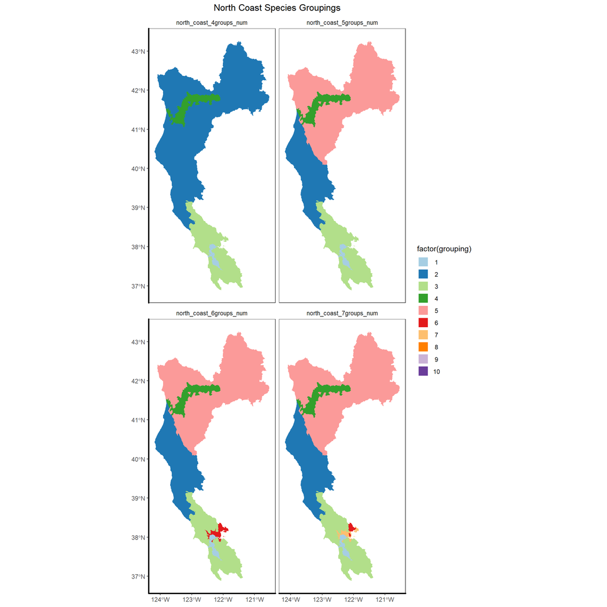

```r
coast_region_name = "north_coast"
coast_species_info <- species_maps(coast_region_name, "North Coast", huc_data)
coast_species_info$region_map  # print the map
```

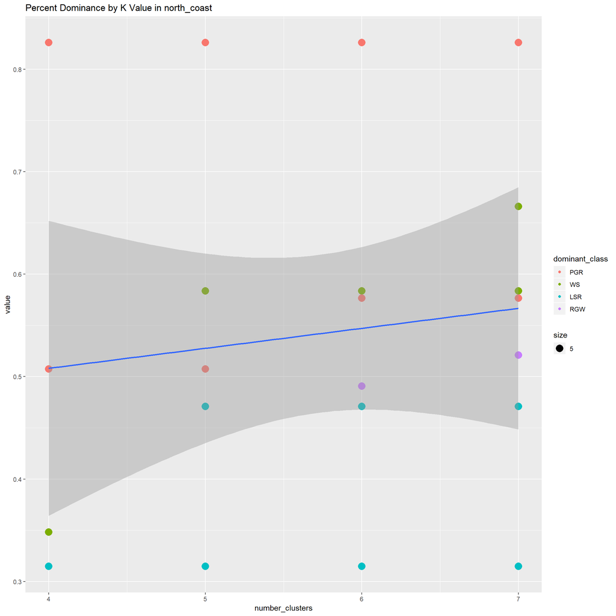

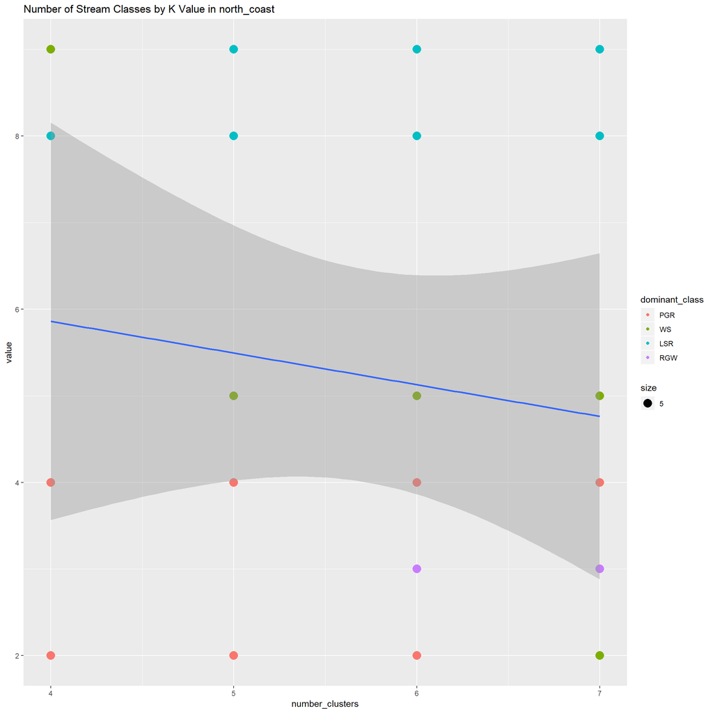

```r
print_dominance_plots(coast_species_info, coast_region_name)
```

```r
coast_species_lists <- species_lists_by_group_dfs(coast_species_info$species_data, coast_region_name)  # species_info$species_data is the data frame for the region
for(df in coast_species_lists){
  show(knitr::kable(df, format="html"))
}
```

| group_1 | group_2 | group_3 | group_4 |
| --- | --- | --- | --- |
| Central_California_coast_winter_steelhead | Blue_chub | California_Coast_fall_Chinook_salmon | Inland_threespine_stickleback |
| Central_Valley_fall_Chinook_salmon | California_Coast_fall_Chinook_salmon | California_roach | Klamath_Mountains_Province_summer_steelhead |
| Central_Valley_late_fall_Chinook_salmon | Central_California_coast_winter_steelhead | Central_California_coast_winter_steelhead | Klamath_Mountains_Province_winter_steelhead |
| Central_Valley_spring_Chinook_salmon | Central_Coast_coho_salmon | Central_Coast_coho_salmon | Klamath_River_lamprey |
| Central_Valley_winter_Chinook_salmon | Hardhead | Central_Valley_spring_Chinook_salmon | Longfin_smelt |
| Delta_smelt | Inland_threespine_stickleback | Delta_smelt | Lower_Klamath_marbled_sculpin |
| Longfin_smelt | Klamath_largescale_sucker | Hardhead | Northern_green_sturgeon |
| Pacific_lamprey | Klamath_Mountains_Province_summer_steelhead | Inland_threespine_stickleback | Pacific_lamprey |
| Sacramento_splittail | Klamath_Mountains_Province_winter_steelhead | Longfin_smelt | River_lamprey |
| Southern_green_sturgeon | Klamath_River_lamprey | Pacific_lamprey | Southern_Oregon_Northern_California_coast_coho_salmon |
| Western_brook_lamprey | Longfin_smelt | Riffle_sculpin | Tidewater_goby |
| White_sturgeon | Lost_River_sucker | River_lamprey | Upper_Klamath_Trinity_fall_Chinook_salmon |
| NA | Northern_California_coast_summer_steelhead | Sacramento_hitch | Upper_Klamath_Trinity_spring_Chinook_salmon |
| NA | Northern_California_coast_winter_steelhead | Sacramento_pikeminnow | Western_brook_lamprey |
| NA | Northern_green_sturgeon | Sacramento_splittail | White_sturgeon |
| NA | Pacific_lamprey | Sacramento_sucker | NA |
| NA | Riffle_sculpin | Sacramento_tule_perch | NA |
| NA | River_lamprey | Southern_coastal_roach | NA |
| NA | Sacramento_pikeminnow | Southern_green_sturgeon | NA |
| NA | Sacramento_sucker | Tidewater_goby | NA |
| NA | Shortnose_sucker | Western_brook_lamprey | NA |
| NA | Southern_Oregon_Northern_California_coast_coho_salmon | White_sturgeon | NA |
| NA | Tidewater_goby | NA | NA |
| NA | Upper_Klamath_marbled_sculpin | NA | NA |
| NA | Upper_Klamath_Trinity_fall_Chinook_salmon | NA | NA |
| NA | Upper_Klamath_Trinity_spring_Chinook_salmon | NA | NA |
| NA | Western_brook_lamprey | NA | NA |
| NA | White_sturgeon | NA | NA |

| group_1 | group_2 | group_3 | group_4 | group_5 |
| --- | --- | --- | --- | --- |
| Central_California_coast_winter_steelhead | California_Coast_fall_Chinook_salmon | California_Coast_fall_Chinook_salmon | Inland_threespine_stickleback | Blue_chub |
| Central_Valley_fall_Chinook_salmon | Central_California_coast_winter_steelhead | California_roach | Klamath_Mountains_Province_summer_steelhead | Inland_threespine_stickleback |
| Central_Valley_late_fall_Chinook_salmon | Central_Coast_coho_salmon | Central_California_coast_winter_steelhead | Klamath_Mountains_Province_winter_steelhead | Klamath_largescale_sucker |
| Central_Valley_spring_Chinook_salmon | Hardhead | Central_Coast_coho_salmon | Klamath_River_lamprey | Klamath_Mountains_Province_summer_steelhead |
| Central_Valley_winter_Chinook_salmon | Inland_threespine_stickleback | Central_Valley_spring_Chinook_salmon | Longfin_smelt | Klamath_Mountains_Province_winter_steelhead |
| Delta_smelt | Longfin_smelt | Delta_smelt | Lower_Klamath_marbled_sculpin | Klamath_River_lamprey |
| Longfin_smelt | Northern_California_coast_summer_steelhead | Hardhead | Northern_green_sturgeon | Lost_River_sucker |
| Pacific_lamprey | Northern_California_coast_winter_steelhead | Inland_threespine_stickleback | Pacific_lamprey | Northern_green_sturgeon |
| Sacramento_splittail | Northern_green_sturgeon | Longfin_smelt | River_lamprey | Pacific_lamprey |
| Southern_green_sturgeon | Pacific_lamprey | Pacific_lamprey | Southern_Oregon_Northern_California_coast_coho_salmon | River_lamprey |
| Western_brook_lamprey | Riffle_sculpin | Riffle_sculpin | Tidewater_goby | Shortnose_sucker |
| White_sturgeon | River_lamprey | River_lamprey | Upper_Klamath_Trinity_fall_Chinook_salmon | Southern_Oregon_Northern_California_coast_coho_salmon |
| NA | Sacramento_pikeminnow | Sacramento_hitch | Upper_Klamath_Trinity_spring_Chinook_salmon | Tidewater_goby |
| NA | Sacramento_sucker | Sacramento_pikeminnow | Western_brook_lamprey | Upper_Klamath_marbled_sculpin |
| NA | Southern_Oregon_Northern_California_coast_coho_salmon | Sacramento_splittail | White_sturgeon | Upper_Klamath_Trinity_fall_Chinook_salmon |
| NA | Tidewater_goby | Sacramento_sucker | NA | Upper_Klamath_Trinity_spring_Chinook_salmon |
| NA | Western_brook_lamprey | Sacramento_tule_perch | NA | Western_brook_lamprey |
| NA | White_sturgeon | Southern_coastal_roach | NA | White_sturgeon |
| NA | NA | Southern_green_sturgeon | NA | NA |
| NA | NA | Tidewater_goby | NA | NA |
| NA | NA | Western_brook_lamprey | NA | NA |
| NA | NA | White_sturgeon | NA | NA |

| group_1 | group_2 | group_3 | group_4 | group_5 | group_6 |
| --- | --- | --- | --- | --- | --- |
| Central_California_coast_winter_steelhead | California_Coast_fall_Chinook_salmon | California_Coast_fall_Chinook_salmon | Inland_threespine_stickleback | Blue_chub | California_roach |
| Central_Valley_fall_Chinook_salmon | Central_California_coast_winter_steelhead | Central_California_coast_winter_steelhead | Klamath_Mountains_Province_summer_steelhead | Inland_threespine_stickleback | Central_California_coast_winter_steelhead |
| Central_Valley_late_fall_Chinook_salmon | Central_Coast_coho_salmon | Central_Coast_coho_salmon | Klamath_Mountains_Province_winter_steelhead | Klamath_largescale_sucker | Delta_smelt |
| Central_Valley_spring_Chinook_salmon | Hardhead | Central_Valley_spring_Chinook_salmon | Klamath_River_lamprey | Klamath_Mountains_Province_summer_steelhead | Hardhead |
| Central_Valley_winter_Chinook_salmon | Inland_threespine_stickleback | Hardhead | Longfin_smelt | Klamath_Mountains_Province_winter_steelhead | Inland_threespine_stickleback |
| Delta_smelt | Longfin_smelt | Inland_threespine_stickleback | Lower_Klamath_marbled_sculpin | Klamath_River_lamprey | Pacific_lamprey |
| Longfin_smelt | Northern_California_coast_summer_steelhead | Longfin_smelt | Northern_green_sturgeon | Lost_River_sucker | River_lamprey |
| Pacific_lamprey | Northern_California_coast_winter_steelhead | Pacific_lamprey | Pacific_lamprey | Northern_green_sturgeon | Sacramento_hitch |
| Sacramento_splittail | Northern_green_sturgeon | Riffle_sculpin | River_lamprey | Pacific_lamprey | Sacramento_pikeminnow |
| Southern_green_sturgeon | Pacific_lamprey | River_lamprey | Southern_Oregon_Northern_California_coast_coho_salmon | River_lamprey | Sacramento_splittail |
| Western_brook_lamprey | Riffle_sculpin | Sacramento_hitch | Tidewater_goby | Shortnose_sucker | Sacramento_sucker |
| White_sturgeon | River_lamprey | Sacramento_pikeminnow | Upper_Klamath_Trinity_fall_Chinook_salmon | Southern_Oregon_Northern_California_coast_coho_salmon | Sacramento_tule_perch |
| NA | Sacramento_pikeminnow | Sacramento_splittail | Upper_Klamath_Trinity_spring_Chinook_salmon | Tidewater_goby | Southern_coastal_roach |
| NA | Sacramento_sucker | Sacramento_sucker | Western_brook_lamprey | Upper_Klamath_marbled_sculpin | Southern_green_sturgeon |
| NA | Southern_Oregon_Northern_California_coast_coho_salmon | Sacramento_tule_perch | White_sturgeon | Upper_Klamath_Trinity_fall_Chinook_salmon | Western_brook_lamprey |
| NA | Tidewater_goby | Southern_coastal_roach | NA | Upper_Klamath_Trinity_spring_Chinook_salmon | White_sturgeon |
| NA | Western_brook_lamprey | Southern_green_sturgeon | NA | Western_brook_lamprey | NA |
| NA | White_sturgeon | Tidewater_goby | NA | White_sturgeon | NA |
| NA | NA | Western_brook_lamprey | NA | NA | NA |
| NA | NA | White_sturgeon | NA | NA | NA |

| group_1 | group_2 | group_3 | group_4 | group_5 | group_6 | group_7 |
| --- | --- | --- | --- | --- | --- | --- |
| Central_California_coast_winter_steelhead | California_Coast_fall_Chinook_salmon | California_Coast_fall_Chinook_salmon | Inland_threespine_stickleback | Blue_chub | California_roach | Central_California_coast_winter_steelhead |
| Central_Valley_fall_Chinook_salmon | Central_California_coast_winter_steelhead | Central_California_coast_winter_steelhead | Klamath_Mountains_Province_summer_steelhead | Inland_threespine_stickleback | Central_California_coast_winter_steelhead | Delta_smelt |
| Central_Valley_late_fall_Chinook_salmon | Central_Coast_coho_salmon | Central_Coast_coho_salmon | Klamath_Mountains_Province_winter_steelhead | Klamath_largescale_sucker | Inland_threespine_stickleback | Hardhead |
| Central_Valley_spring_Chinook_salmon | Hardhead | Central_Valley_spring_Chinook_salmon | Klamath_River_lamprey | Klamath_Mountains_Province_summer_steelhead | Pacific_lamprey | Inland_threespine_stickleback |
| Central_Valley_winter_Chinook_salmon | Inland_threespine_stickleback | Hardhead | Longfin_smelt | Klamath_Mountains_Province_winter_steelhead | River_lamprey | Pacific_lamprey |
| Delta_smelt | Longfin_smelt | Inland_threespine_stickleback | Lower_Klamath_marbled_sculpin | Klamath_River_lamprey | Sacramento_hitch | River_lamprey |
| Longfin_smelt | Northern_California_coast_summer_steelhead | Longfin_smelt | Northern_green_sturgeon | Lost_River_sucker | Sacramento_pikeminnow | Sacramento_hitch |
| Pacific_lamprey | Northern_California_coast_winter_steelhead | Pacific_lamprey | Pacific_lamprey | Northern_green_sturgeon | Sacramento_sucker | Sacramento_pikeminnow |
| Sacramento_splittail | Northern_green_sturgeon | Riffle_sculpin | River_lamprey | Pacific_lamprey | Sacramento_tule_perch | Sacramento_splittail |
| Southern_green_sturgeon | Pacific_lamprey | River_lamprey | Southern_Oregon_Northern_California_coast_coho_salmon | River_lamprey | Southern_green_sturgeon | Sacramento_sucker |
| Western_brook_lamprey | Riffle_sculpin | Sacramento_hitch | Tidewater_goby | Shortnose_sucker | Western_brook_lamprey | Sacramento_tule_perch |
| White_sturgeon | River_lamprey | Sacramento_pikeminnow | Upper_Klamath_Trinity_fall_Chinook_salmon | Southern_Oregon_Northern_California_coast_coho_salmon | White_sturgeon | Southern_coastal_roach |
| NA | Sacramento_pikeminnow | Sacramento_splittail | Upper_Klamath_Trinity_spring_Chinook_salmon | Tidewater_goby | NA | Southern_green_sturgeon |
| NA | Sacramento_sucker | Sacramento_sucker | Western_brook_lamprey | Upper_Klamath_marbled_sculpin | NA | Western_brook_lamprey |
| NA | Southern_Oregon_Northern_California_coast_coho_salmon | Sacramento_tule_perch | White_sturgeon | Upper_Klamath_Trinity_fall_Chinook_salmon | NA | White_sturgeon |
| NA | Tidewater_goby | Southern_coastal_roach | NA | Upper_Klamath_Trinity_spring_Chinook_salmon | NA | NA |
| NA | Western_brook_lamprey | Southern_green_sturgeon | NA | Western_brook_lamprey | NA | NA |
| NA | White_sturgeon | Tidewater_goby | NA | White_sturgeon | NA | NA |
| NA | NA | Western_brook_lamprey | NA | NA | NA | NA |
| NA | NA | White_sturgeon | NA | NA | NA | NA |

## South Coast

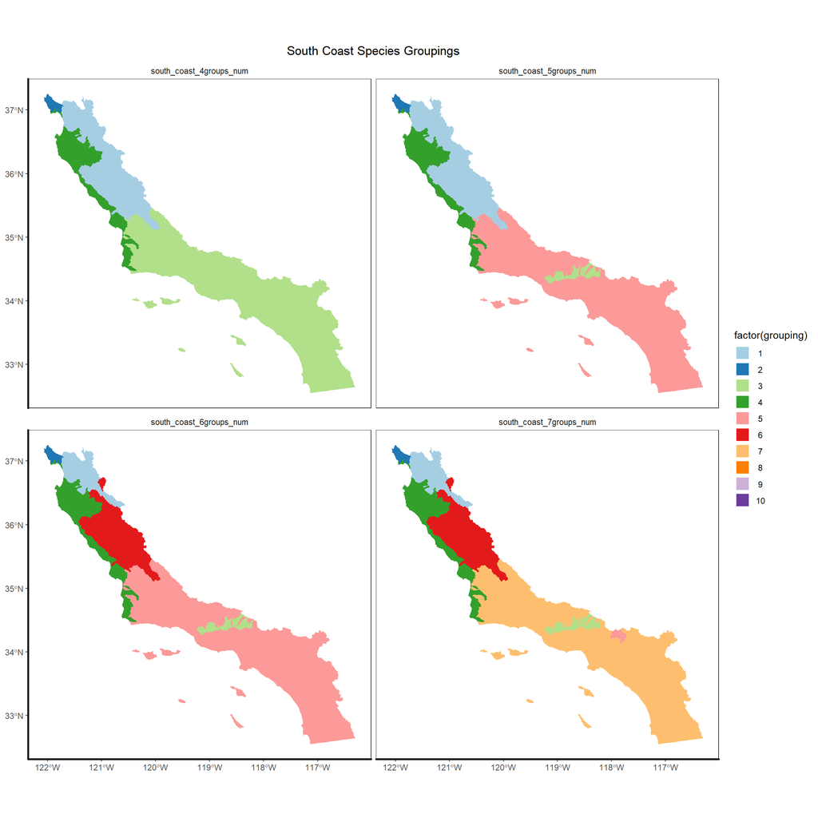

```r
soco_region_name = "south_coast"
soco_species_info <- species_maps(soco_region_name, "South Coast", huc_data)
soco_species_info$region_map  # print the map
```

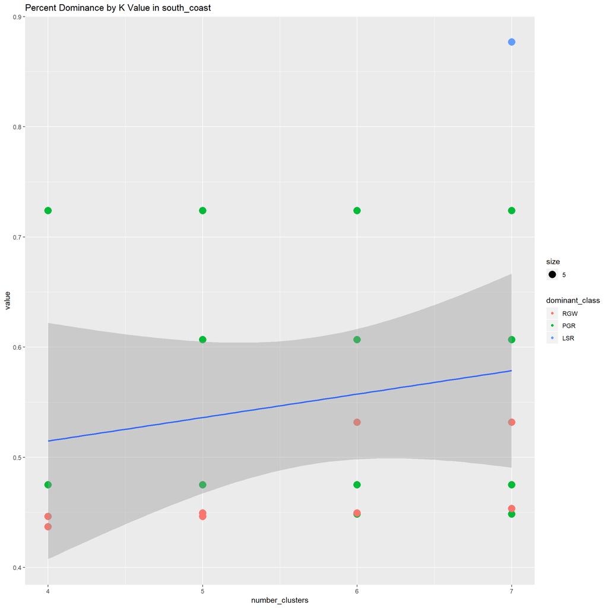

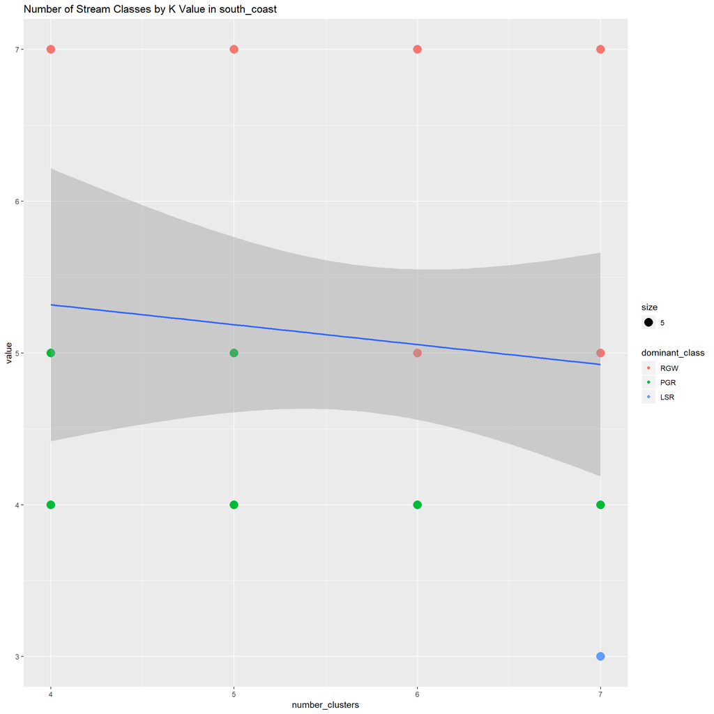

```r
print_dominance_plots(soco_species_info, soco_region_name)
```

```r
soco_species_lists <- species_lists_by_group_dfs(soco_species_info$species_data, soco_region_name)  # species_info$species_data is the data frame for the region
for(df in soco_species_lists){
  show(knitr::kable(df, format="html"))
}
```

| group_1 | group_2 | group_3 | group_4 |
| --- | --- | --- | --- |
| Inland_threespine_stickleback | Central_California_coast_winter_steelhead | Arroyo_chub | Inland_threespine_stickleback |
| Monterey_hitch | Inland_threespine_stickleback | Inland_threespine_stickleback | Monterey_hitch |
| Monterey_sucker | Pacific_lamprey | Pacific_lamprey | Monterey_sucker |
| Pacific_lamprey | Sacramento_speckled_dace | Sacramento_pikeminnow | Pacific_lamprey |
| Riffle_sculpin | Southern_coastal_roach | Santa_Ana_speckled_dace | Sacramento_pikeminnow |
| Sacramento_pikeminnow | Tidewater_goby | Santa_Ana_sucker | Sacramento_speckled_dace |
| Sacramento_speckled_dace | NA | South_Central_California_coast_steelhead | South_Central_California_coast_steelhead |
| South_Central_California_coast_steelhead | NA | Southern_California_steelhead | Southern_California_steelhead |
| Southern_coastal_roach | NA | Tidewater_goby | Southern_coastal_roach |
| Tidewater_goby | NA | Unarmored_threespine_stickleback | Tidewater_goby |
| NA | NA | NA | Unarmored_threespine_stickleback |

| group_1 | group_2 | group_3 | group_4 | group_5 |
| --- | --- | --- | --- | --- |
| Inland_threespine_stickleback | Central_California_coast_winter_steelhead | Pacific_lamprey | Inland_threespine_stickleback | Arroyo_chub |
| Monterey_hitch | Inland_threespine_stickleback | Southern_California_steelhead | Monterey_hitch | Inland_threespine_stickleback |
| Monterey_sucker | Pacific_lamprey | Unarmored_threespine_stickleback | Monterey_sucker | Pacific_lamprey |
| Pacific_lamprey | Sacramento_speckled_dace | NA | Pacific_lamprey | Sacramento_pikeminnow |
| Riffle_sculpin | Southern_coastal_roach | NA | Sacramento_pikeminnow | Santa_Ana_speckled_dace |
| Sacramento_pikeminnow | Tidewater_goby | NA | Sacramento_speckled_dace | Santa_Ana_sucker |
| Sacramento_speckled_dace | NA | NA | South_Central_California_coast_steelhead | South_Central_California_coast_steelhead |
| South_Central_California_coast_steelhead | NA | NA | Southern_California_steelhead | Southern_California_steelhead |
| Southern_coastal_roach | NA | NA | Southern_coastal_roach | Tidewater_goby |
| Tidewater_goby | NA | NA | Tidewater_goby | NA |
| NA | NA | NA | Unarmored_threespine_stickleback | NA |

| group_1 | group_2 | group_3 | group_4 | group_5 | group_6 |
| --- | --- | --- | --- | --- | --- |
| Inland_threespine_stickleback | Central_California_coast_winter_steelhead | Pacific_lamprey | Inland_threespine_stickleback | Arroyo_chub | Inland_threespine_stickleback |
| Monterey_hitch | Inland_threespine_stickleback | Southern_California_steelhead | Monterey_hitch | Inland_threespine_stickleback | Monterey_hitch |
| Monterey_sucker | Pacific_lamprey | Unarmored_threespine_stickleback | Monterey_sucker | Pacific_lamprey | Monterey_sucker |
| Pacific_lamprey | Sacramento_speckled_dace | NA | Pacific_lamprey | Sacramento_pikeminnow | Pacific_lamprey |
| Riffle_sculpin | Southern_coastal_roach | NA | Sacramento_pikeminnow | Santa_Ana_speckled_dace | Riffle_sculpin |
| Sacramento_pikeminnow | Tidewater_goby | NA | Sacramento_speckled_dace | Santa_Ana_sucker | Sacramento_pikeminnow |
| Sacramento_speckled_dace | NA | NA | South_Central_California_coast_steelhead | South_Central_California_coast_steelhead | South_Central_California_coast_steelhead |
| South_Central_California_coast_steelhead | NA | NA | Southern_California_steelhead | Southern_California_steelhead | NA |
| Southern_coastal_roach | NA | NA | Southern_coastal_roach | Tidewater_goby | NA |
| Tidewater_goby | NA | NA | Tidewater_goby | NA | NA |
| NA | NA | NA | Unarmored_threespine_stickleback | NA | NA |

| group_1 | group_2 | group_3 | group_4 | group_5 | group_6 | group_7 |
| --- | --- | --- | --- | --- | --- | --- |
| Inland_threespine_stickleback | Central_California_coast_winter_steelhead | Pacific_lamprey | Inland_threespine_stickleback | Arroyo_chub | Inland_threespine_stickleback | Arroyo_chub |
| Monterey_hitch | Inland_threespine_stickleback | Southern_California_steelhead | Monterey_hitch | Santa_Ana_speckled_dace | Monterey_hitch | Inland_threespine_stickleback |
| Monterey_sucker | Pacific_lamprey | Unarmored_threespine_stickleback | Monterey_sucker | Santa_Ana_sucker | Monterey_sucker | Pacific_lamprey |
| Pacific_lamprey | Sacramento_speckled_dace | NA | Pacific_lamprey | NA | Pacific_lamprey | Sacramento_pikeminnow |
| Riffle_sculpin | Southern_coastal_roach | NA | Sacramento_pikeminnow | NA | Riffle_sculpin | Santa_Ana_speckled_dace |
| Sacramento_pikeminnow | Tidewater_goby | NA | Sacramento_speckled_dace | NA | Sacramento_pikeminnow | Santa_Ana_sucker |
| Sacramento_speckled_dace | NA | NA | South_Central_California_coast_steelhead | NA | South_Central_California_coast_steelhead | South_Central_California_coast_steelhead |
| South_Central_California_coast_steelhead | NA | NA | Southern_California_steelhead | NA | NA | Southern_California_steelhead |
| Southern_coastal_roach | NA | NA | Southern_coastal_roach | NA | NA | Tidewater_goby |
| Tidewater_goby | NA | NA | Tidewater_goby | NA | NA | NA |
| NA | NA | NA | Unarmored_threespine_stickleback | NA | NA | NA |